# ProsperLoanProject

### Preliminary Wrangling

```python
# import all packages and set plots to be embedded inline
import numpy as np
import pandas as pd
import matplotlib.pyplot as plt
import seaborn as sb

%matplotlib inline
```

```python
# load in the dataset into a pandas dataframe
loans = pd.read_csv('prosperLoanData.csv')
```

## Dataset Overview

```python
loans.head()
```

|  | ListingKey | ListingNumber | ListingCreationDate | CreditGrade | Term | LoanStatus | ClosedDate | BorrowerAPR | BorrowerRate | LenderYield | ... | LP_ServiceFees | LP_CollectionFees | LP_GrossPrincipalLoss | LP_NetPrincipalLoss | LP_NonPrincipalRecoverypayments | PercentFunded | Recommendations | InvestmentFromFriendsCount | InvestmentFromFriendsAmount | Investors |
| --- | --- | --- | --- | --- | --- | --- | --- | --- | --- | --- | --- | --- | --- | --- | --- | --- | --- | --- | --- | --- | --- |
| 0 | 1021339766868145413AB3B | 193129 | 2007-08-26 19:09:29.263000000 | C | 36 | Completed | 2009-08-14 00:00:00 | 0.16516 | 0.1580 | 0.1380 | ... | -133.18 | 0.0 | 0.0 | 0.0 | 0.0 | 1.0 | 0 | 0 | 0.0 | 258 |
| 1 | 10273602499503308B223C1 | 1209647 | 2014-02-27 08:28:07.900000000 | NaN | 36 | Current | NaN | 0.12016 | 0.0920 | 0.0820 | ... | 0.00 | 0.0 | 0.0 | 0.0 | 0.0 | 1.0 | 0 | 0 | 0.0 | 1 |
| 2 | 0EE9337825851032864889A | 81716 | 2007-01-05 15:00:47.090000000 | HR | 36 | Completed | 2009-12-17 00:00:00 | 0.28269 | 0.2750 | 0.2400 | ... | -24.20 | 0.0 | 0.0 | 0.0 | 0.0 | 1.0 | 0 | 0 | 0.0 | 41 |
| 3 | 0EF5356002482715299901A | 658116 | 2012-10-22 11:02:35.010000000 | NaN | 36 | Current | NaN | 0.12528 | 0.0974 | 0.0874 | ... | -108.01 | 0.0 | 0.0 | 0.0 | 0.0 | 1.0 | 0 | 0 | 0.0 | 158 |
| 4 | 0F023589499656230C5E3E2 | 909464 | 2013-09-14 18:38:39.097000000 | NaN | 36 | Current | NaN | 0.24614 | 0.2085 | 0.1985 | ... | -60.27 | 0.0 | 0.0 | 0.0 | 0.0 | 1.0 | 0 | 0 | 0.0 | 20 |

5 rows × 81 columns

```python
## high-level overview of data shape and composition
```

```python
loans.shape
```

```
(113937, 81)
```

```python
loans.info()
```

```
<class 'pandas.core.frame.DataFrame'>
RangeIndex: 113937 entries, 0 to 113936
Data columns (total 81 columns):
ListingKey                             113937 non-null object
ListingNumber                          113937 non-null int64
ListingCreationDate                    113937 non-null object
CreditGrade                            28953 non-null object
Term                                   113937 non-null int64
LoanStatus                             113937 non-null object
ClosedDate                             55089 non-null object
BorrowerAPR                            113912 non-null float64
BorrowerRate                           113937 non-null float64
LenderYield                            113937 non-null float64
EstimatedEffectiveYield                84853 non-null float64
EstimatedLoss                          84853 non-null float64
EstimatedReturn                        84853 non-null float64
ProsperRating (numeric)                84853 non-null float64
ProsperRating (Alpha)                  84853 non-null object
ProsperScore                           84853 non-null float64
ListingCategory (numeric)              113937 non-null int64
BorrowerState                          108422 non-null object
Occupation                             110349 non-null object
EmploymentStatus                       111682 non-null object
EmploymentStatusDuration               106312 non-null float64
IsBorrowerHomeowner                    113937 non-null bool
CurrentlyInGroup                       113937 non-null bool
GroupKey                               13341 non-null object
DateCreditPulled                       113937 non-null object
CreditScoreRangeLower                  113346 non-null float64
CreditScoreRangeUpper                  113346 non-null float64
FirstRecordedCreditLine                113240 non-null object
CurrentCreditLines                     106333 non-null float64
OpenCreditLines                        106333 non-null float64
TotalCreditLinespast7years             113240 non-null float64
OpenRevolvingAccounts                  113937 non-null int64
OpenRevolvingMonthlyPayment            113937 non-null float64
InquiriesLast6Months                   113240 non-null float64
TotalInquiries                         112778 non-null float64
CurrentDelinquencies                   113240 non-null float64
AmountDelinquent                       106315 non-null float64
```

[output cut: 31 more lines]

```
LP_CustomerPayments                    113937 non-null float64
LP_CustomerPrincipalPayments           113937 non-null float64
LP_InterestandFees                     113937 non-null float64
LP_ServiceFees                         113937 non-null float64
LP_CollectionFees                      113937 non-null float64
LP_GrossPrincipalLoss                  113937 non-null float64
LP_NetPrincipalLoss                    113937 non-null float64
LP_NonPrincipalRecoverypayments        113937 non-null float64
PercentFunded                          113937 non-null float64
Recommendations                        113937 non-null int64
InvestmentFromFriendsCount             113937 non-null int64
InvestmentFromFriendsAmount            113937 non-null float64
Investors                              113937 non-null int64
dtypes: bool(3), float64(50), int64(11), object(17)
memory usage: 68.1+ MB
```

```python
# descriptive statistics for numeric variables
loans.describe()
```

|  | ListingNumber | Term | BorrowerAPR | BorrowerRate | LenderYield | EstimatedEffectiveYield | EstimatedLoss | EstimatedReturn | ProsperRating (numeric) | ProsperScore | ... | LP_ServiceFees | LP_CollectionFees | LP_GrossPrincipalLoss | LP_NetPrincipalLoss | LP_NonPrincipalRecoverypayments | PercentFunded | Recommendations | InvestmentFromFriendsCount | InvestmentFromFriendsAmount | Investors |
| --- | --- | --- | --- | --- | --- | --- | --- | --- | --- | --- | --- | --- | --- | --- | --- | --- | --- | --- | --- | --- | --- |
| count | 1.139370e+05 | 113937.000000 | 113912.000000 | 113937.000000 | 113937.000000 | 84853.000000 | 84853.000000 | 84853.000000 | 84853.000000 | 84853.000000 | ... | 113937.000000 | 113937.000000 | 113937.000000 | 113937.000000 | 113937.000000 | 113937.000000 | 113937.000000 | 113937.000000 | 113937.000000 | 113937.000000 |
| mean | 6.278857e+05 | 40.830248 | 0.218828 | 0.192764 | 0.182701 | 0.168661 | 0.080306 | 0.096068 | 4.072243 | 5.950067 | ... | -54.725641 | -14.242698 | 700.446342 | 681.420499 | 25.142686 | 0.998584 | 0.048027 | 0.023460 | 16.550751 | 80.475228 |
| std | 3.280762e+05 | 10.436212 | 0.080364 | 0.074818 | 0.074516 | 0.068467 | 0.046764 | 0.030403 | 1.673227 | 2.376501 | ... | 60.675425 | 109.232758 | 2388.513831 | 2357.167068 | 275.657937 | 0.017919 | 0.332353 | 0.232412 | 294.545422 | 103.239020 |
| min | 4.000000e+00 | 12.000000 | 0.006530 | 0.000000 | -0.010000 | -0.182700 | 0.004900 | -0.182700 | 1.000000 | 1.000000 | ... | -664.870000 | -9274.750000 | -94.200000 | -954.550000 | 0.000000 | 0.700000 | 0.000000 | 0.000000 | 0.000000 | 1.000000 |
| 25% | 4.009190e+05 | 36.000000 | 0.156290 | 0.134000 | 0.124200 | 0.115670 | 0.042400 | 0.074080 | 3.000000 | 4.000000 | ... | -73.180000 | 0.000000 | 0.000000 | 0.000000 | 0.000000 | 1.000000 | 0.000000 | 0.000000 | 0.000000 | 2.000000 |
| 50% | 6.005540e+05 | 36.000000 | 0.209760 | 0.184000 | 0.173000 | 0.161500 | 0.072400 | 0.091700 | 4.000000 | 6.000000 | ... | -34.440000 | 0.000000 | 0.000000 | 0.000000 | 0.000000 | 1.000000 | 0.000000 | 0.000000 | 0.000000 | 44.000000 |
| 75% | 8.926340e+05 | 36.000000 | 0.283810 | 0.250000 | 0.240000 | 0.224300 | 0.112000 | 0.116600 | 5.000000 | 8.000000 | ... | -13.920000 | 0.000000 | 0.000000 | 0.000000 | 0.000000 | 1.000000 | 0.000000 | 0.000000 | 0.000000 | 115.000000 |
| max | 1.255725e+06 | 60.000000 | 0.512290 | 0.497500 | 0.492500 | 0.319900 | 0.366000 | 0.283700 | 7.000000 | 11.000000 | ... | 32.060000 | 0.000000 | 25000.000000 | 25000.000000 | 21117.900000 | 1.012500 | 39.000000 | 33.000000 | 25000.000000 | 1189.000000 |

8 rows × 61 columns

### What is the structure of the data?

> the data consists of 81 record for each loan, some of these data has null values and some has non-valuable data. These data is ranged between 2005 and 2014 with various characteristics of those loans. Out of these data there are 61 numeric variables and 20 objectis variables. I will work on 18 variables out of 18 and they are consisting of 5 discrete variables and 13 continuous variables.

### What are the main features of interest in the dataset?

> I am most interested to see the some data related to the borrowers such as income to dept ratio and what they can afford on monthly baseis. Also I want to investigate some data related to the loan it self such as Loan Origination Quarter, loan status, APR.

### What features in the dataset do you think will help support your investigation into your features of interest?

> Iam not a sepcialest in this feild, but I expect that occupation and monthly income will affect the loan amount and its annual interest. There are a lot of data about the borrower, so I think by multivariant analysis these vaibales I could find intersting things.

## Univariate Exploration

- I will begin my investigation by detecting which quarter has the most loan origination.

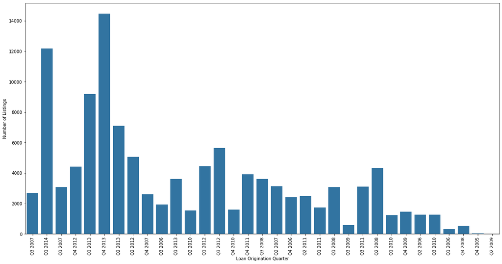

```python
#univariate plot of loan origination quarter
plt.figure(figsize=(20,10))
base_color = sb.color_palette()[0]
sb.countplot(data = loans , x = 'LoanOriginationQuarter', color=base_color)
plt.xlabel('Loan Origination Quarter')
plt.ylabel('Number of Listings')
plt.xticks(rotation=90);
```

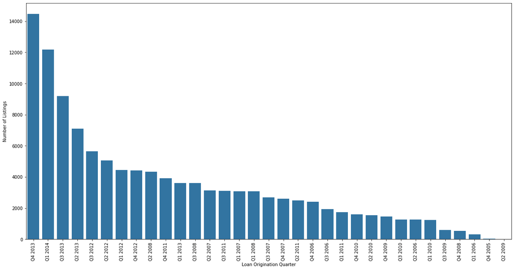

```python
#to check which quarter has more frequent of loan generation
freq = loans['LoanOriginationQuarter'].value_counts()
gen_order = freq.index
plt.figure(figsize=(20,10))
sb.countplot(data = loans , x = 'LoanOriginationQuarter', color=base_color, order=gen_order)
plt.xlabel('Loan Origination Quarter')
plt.ylabel('Number of Listings')
plt.xticks(rotation=90);
```

```python
# check the trend of load orgination years
# first get the Quarters
loans['LoanOriginationQuarter'].values
```

[output not shown]

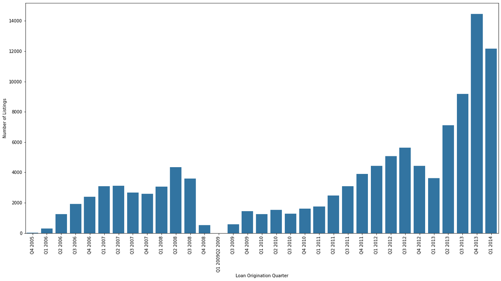

```python
# make the 'LoanOriginationQuarter' categorical data type
quarter = ['Q4 2005', 'Q1 2006', 'Q2 2006', 'Q3 2006', 'Q4 2006', 'Q1 2007', 'Q2 2007', 'Q3 2007', 'Q4 2007', 'Q1 2008', 'Q2 2008', 'Q3 2008', 'Q4 2008', 'Q1 2009'
          'Q2 2009', 'Q3 2009', 'Q4 2009', 'Q1 2010', 'Q2 2010', 'Q3 2010', 'Q4 2010', 'Q1 2011', 'Q2 2011', 'Q3 2011', 'Q4 2011', 'Q1 2012', 'Q2 2012', 'Q3 2012', 'Q4 2012',
          'Q1 2013', 'Q2 2013', 'Q3 2013', 'Q4 2013', 'Q1 2014']
cat = pd.api.types.CategoricalDtype(categories=quarter, ordered=True)
loans['LoanOriginationQuarter'] = loans['LoanOriginationQuarter'].astype(cat)
loans = loans.loc[loans['LoanOriginationQuarter'].isin(['Q4 2005', 'Q1 2006', 'Q2 2006', 'Q3 2006', 'Q4 2006', 'Q1 2007', 'Q2 2007', 'Q3 2007', 'Q4 2007', 'Q1 2008', 'Q2 2008', 'Q3 2008', 'Q4 2008',
          'Q1 2009' ,'Q2 2009', 'Q3 2009', 'Q4 2009', 'Q1 2010', 'Q2 2010', 'Q3 2010', 'Q4 2010', 'Q1 2011', 'Q2 2011', 'Q3 2011', 'Q4 2011', 'Q1 2012', 'Q2 2012', 'Q3 2012', 'Q4 2012',
          'Q1 2013', 'Q2 2013', 'Q3 2013', 'Q4 2013', 'Q1 2014'])]
plt.figure(figsize=(20,10))
sb.countplot(data = loans , x = 'LoanOriginationQuarter', color=base_color)
plt.xlabel('Loan Origination Quarter')
plt.ylabel('Number of Listings')
plt.xticks(rotation=90);
```

> from pervious figure its obvisuly now that origination loans trend start to increase from the first quarter of 2006 then faill in the last quarter of 2008 till Q3 2009, I think this is where the world econonmy has been failld. I have found this on the balance web site ("The 2008 financial crisis was the worst economic disaster since the Great Depression of 1929. It occurred despite the efforts of the Federal Reserve and the U.S. Department of the Treasury. The crisis led to the Great Recession, where housing prices dropped more than the price plunge during the Great Depression. Two years after the recession ended, unemployment was still above 9%. That doesn't count those discouraged workers who had given up looking for a job.") It has been noticed also that after 2009 the loan origination begain to increase with little fluctuation till the end of the series.
- Let's check now What is the Loan amount?

```python
#check the statistics of loan amount
loans['LoanOriginalAmount'].describe()
```

```
count    113937.00000
mean       8337.01385
std        6245.80058
min        1000.00000
25%        4000.00000
50%        6500.00000
75%       12000.00000
max       35000.00000
Name: LoanOriginalAmount, dtype: float64
```

> I noticed that the loan ranged between 1000 US dollar to 35000 US dollar with average value of 8337 US dollar.

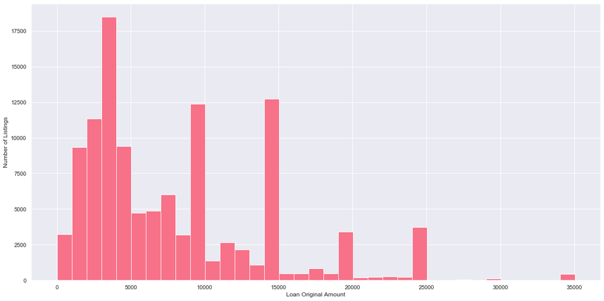

```python
# visualize the loan amount
plt.figure(figsize=(20,10))
bins = np.arange(20, loans['LoanOriginalAmount'].max()+1000,1000)
plt.hist(loans['LoanOriginalAmount'], bins = bins)
plt.xlabel('Loan Original Amount')
plt.ylabel('Number of Listings');
```

> This chart represent the loan amount and Number of brrowers for each value. It's right skewed chart with median less than mean. this is means that most of Borrowers take amounts less than 10000 US dollar. Now let's investegate why is this?

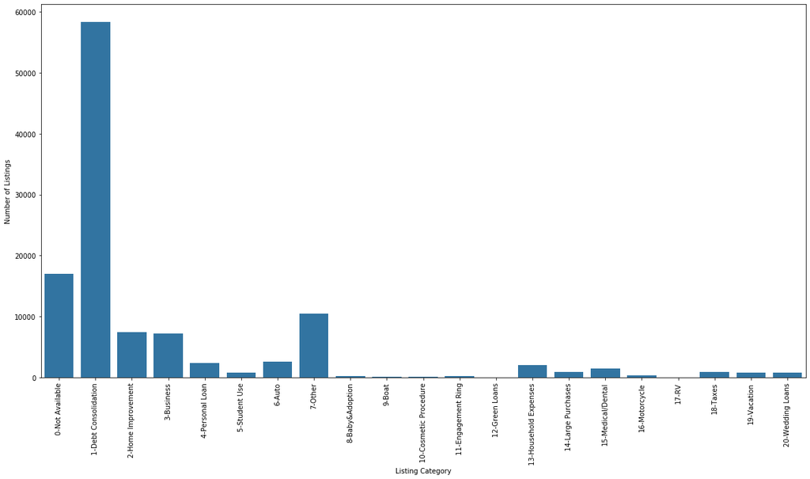

```python
#univariate plot of listing category, create xstick labels
plt.figure(figsize=(20,10))
listing = sb.countplot(data = loans, x = 'ListingCategory (numeric)', color = base_color)
plt.xlabel('Listing Category')
plt.ylabel('Number of Listings')
xlabels = ['0-Not Available', '1-Debt Consolidation', '2-Home Improvement', '3-Business', '4-Personal Loan', '5-Student Use', '6-Auto', '7-Other', '8-Baby&Adoption', '9-Boat', '10-Cosmetic Procedure', '11-Engagement Ring', '12-Green Loans', '13-Household Expenses', '14-Large Purchases', '15-Medical/Dental', '16-Motorcycle', '17-RV', '18-Taxes', '19-Vacation', '20-Wedding Loans']
listing.set_xticklabels(xlabels, rotation=90);
```

> So the loan which has more brrowers is debt Debt Consolidation. Debt consolidation means combining more than one debt obligation into a new loan with a favourable term structure such as lower interest rate structure, tenure, etc. Here, the amount received from the new loan is used to pay off other debts.
- Let's check now the stause of these loans and the percentage of brrowers.

```python
status = ['Cancelled', 'Chargedoff', 'Completed', 'Current, Defaulted', 'FinalPaymentInProgress']
stat = pd.api.types.CategoricalDtype(ordered = True, categories = status)
loans['LoanStatus'] = loans['LoanStatus'].astype(stat)
loans.groupby('LoanStatus')['ListingNumber'].count()
```

```
LoanStatus
Cancelled                     5
Chargedoff                11992
Completed                 38074
Current, Defaulted            0
FinalPaymentInProgress      205
Name: ListingNumber, dtype: int64
```

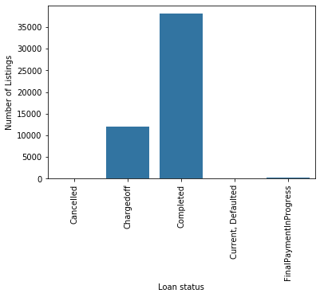

```python
# Plot the loan status
sb.countplot(data = loans, x = 'LoanStatus', color = base_color);
plt.xlabel('Loan status')
plt.ylabel('Number of Listings')
plt.xticks(rotation=90);
```

  > APR is the annual cost of a loan to a borrower — including fees. Like an interest rate, the APR is expressed as a percentage. Unlike an interest rate, however, it includes other charges or fees such as mortgage insurance, most closing costs, discount points and loan origination fees.

> Lets check this

```python
#check the average borrower APR
loans['BorrowerAPR'].describe()
```

```
count    113912.000000
mean          0.218828
std           0.080364
min           0.006530
25%           0.156290
50%           0.209760
75%           0.283810
max           0.512290
Name: BorrowerAPR, dtype: float64
```

> It has some null values. The maximum value is 50% and the min is 0.6%, with an avergae value of 22%.

I will first fill in the null values with the mean

```python
# filling in missing values of brrowers APR with the mean
loans.BorrowerAPR = loans.BorrowerAPR.fillna(loans.BorrowerAPR.mean())
loans['BorrowerAPR'].describe()
```

```
count    113937.000000
mean          0.218828
std           0.080355
min           0.006530
25%           0.156290
50%           0.209790
75%           0.283700
max           0.512290
Name: BorrowerAPR, dtype: float64
```

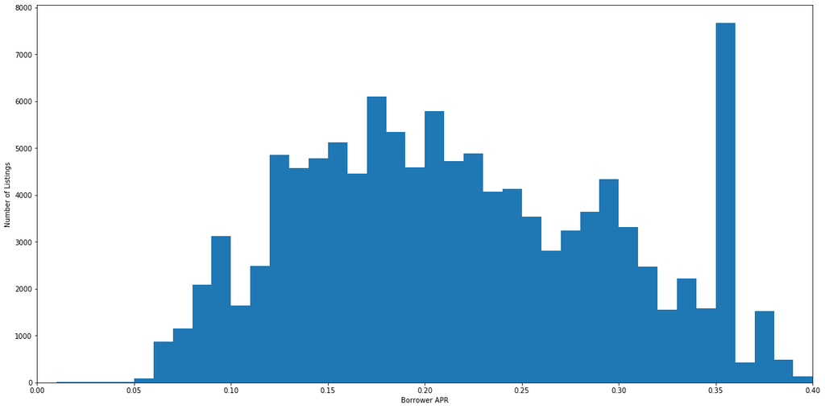

```python
#Visualize thses records using histogram
bin_size = 0.01
bins = np.arange(0, loans ['BorrowerAPR'].max()+bin_size, bin_size)
plt.figure(figsize=[20,10])
plt.hist(data = loans, x = 'BorrowerAPR', bins = bins)
plt.xlim([0,0.4])
plt.xlabel('Borrower APR')
plt.ylabel('Number of Listings')
plt.show()
```

```python
#check the decribtion of borrower rate
loans['BorrowerRate'].describe()
```

```
count    113937.000000
mean          0.192764
std           0.074818
min           0.000000
25%           0.134000
50%           0.184000
75%           0.250000
max           0.497500
Name: BorrowerRate, dtype: float64
```

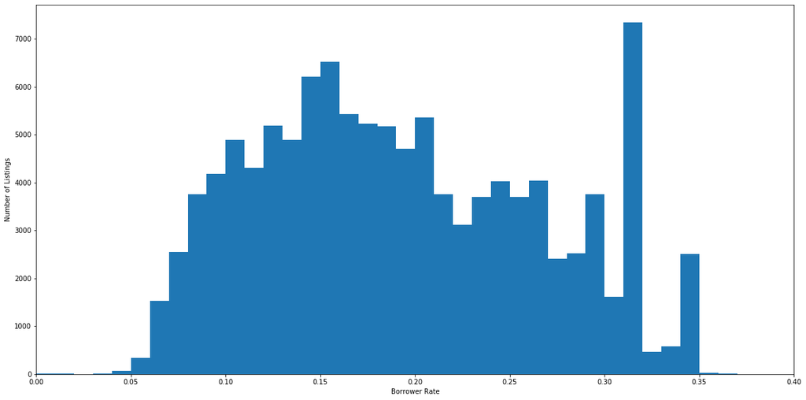

```python
bin_size = 0.01
bins = np.arange(0, loans ['BorrowerRate'].max()+bin_size, bin_size)
plt.figure(figsize=[20,10])
plt.hist(data = loans, x = 'BorrowerRate', bins = bins)
plt.xlim([0,0.4])
plt.xlabel('Borrower Rate')
plt.ylabel('Number of Listings')
plt.show()
```

```python
#check the describtion of borrower rate
loans['EmploymentStatus'].value_counts()
```

```
Employed         67322
Full-time        26355
Self-employed     6134
Not available     5347
Other             3806
Part-time         1088
Not employed       835
Retired            795
Name: EmploymentStatus, dtype: int64
```

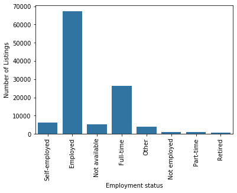

```python
# Plot the employment status
sb.countplot(data = loans, x = 'EmploymentStatus', color = base_color);
plt.xlabel('Employment status')
plt.ylabel('Number of Listings')
plt.xticks(rotation=90);
```

> We noticed here that the bank accept all kinds of employment, from not employed and retired to full time job employe
- Now we will see which job that their employes have more loans

```python
loans['Occupation'].value_counts()
```

```
Other                          28617
Professional                   13628
Computer Programmer             4478
Executive                       4311
Teacher                         3759
                               ...
Dentist                           68
Student - College Freshman        41
Student - Community College       28
Judge                             22
Student - Technical School        16
Name: Occupation, Length: 67, dtype: int64
```

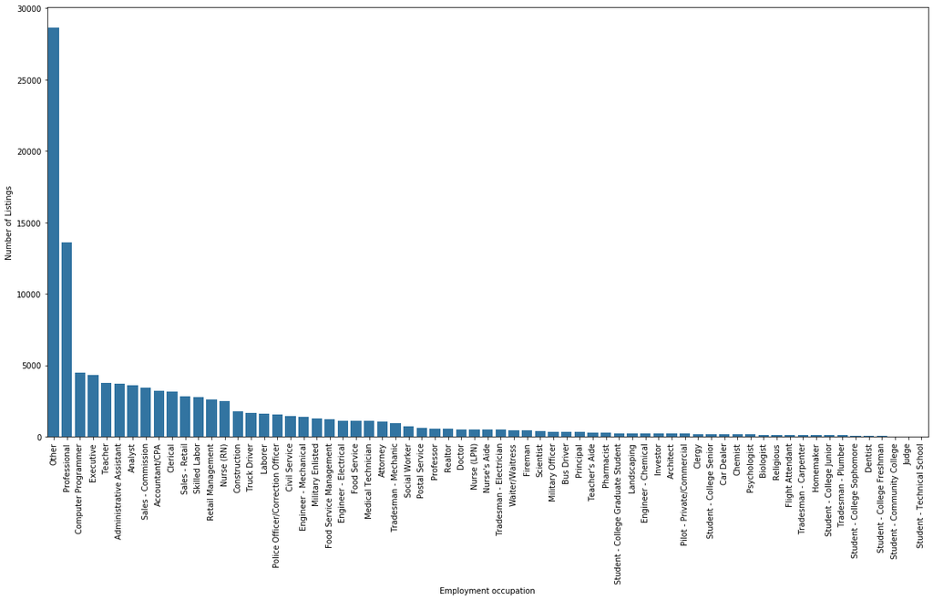

```python
#arrange them in descending order
occ_order = loans['Occupation'].value_counts().index
# Plot the employment status
plt.figure(figsize=(20,10))
sb.countplot(data = loans, x = 'Occupation', color = base_color, order= occ_order);
plt.xlabel('Employment occupation')
plt.ylabel('Number of Listings')
plt.xticks(rotation=90);
```

```python
# get the statistics data for the instullment
loans['MonthlyLoanPayment'].describe()
```

```
count    113937.000000
mean        272.475783
std         192.697812
min           0.000000
25%         131.620000
50%         217.740000
75%         371.580000
max        2251.510000
Name: MonthlyLoanPayment, dtype: float64
```

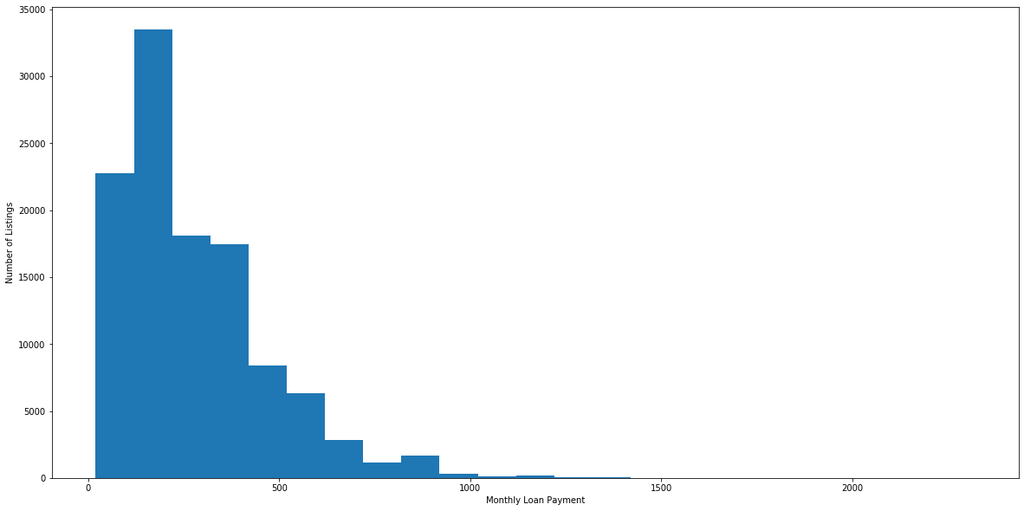

```python
# visualize these values
plt.figure(figsize=(20,10))
bins = np.arange(20, loans['MonthlyLoanPayment'].max()+100,100)
plt.hist(loans['MonthlyLoanPayment'], bins = bins)
plt.xlabel('Monthly Loan Payment')
plt.ylabel('Number of Listings');
```

> From above chart and statistics I find that the data has right skewed as mean (272 us dollar) > median (217 us dollar). This means that most of monthly payment is less than 1000 us dollar, I think that this is why every body can take a loan.
- The next question that raise into my mind, what is the monthly income for those brrowers?

```python
# get the statistics data for the instullment
loans['IncomeRange'].describe()
```

```
count             113937
unique                 8
top       $25,000-49,999
freq               32192
Name: IncomeRange, dtype: object
```

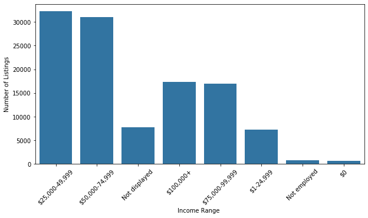

```python
#visualization for income range
plt.figure(figsize=(10,5))
sb.countplot(data = loans, x = 'IncomeRange', color = base_color);
plt.xlabel('Income Range ')
plt.ylabel('Number of Listings')
plt.xticks(rotation=45);
```

> More than 60000 has income more than 25 000 dollar. About 30 000 has income more than 75 000 dollars.

```python
#statistics income verifiable
loans['IncomeVerifiable'].describe()
```

```
count     113937
unique         2
top         True
freq      105268
Name: IncomeVerifiable, dtype: object
```

```python
loans['IncomeVerifiable'].value_counts()
```

```
True     105268
False      8669
Name: IncomeVerifiable, dtype: int64
```

> More than 105 thousand person should provide the required documentation to support their income.
- Lets now study the Stated Monthly Income for brrowers

```python
#StatedMonthlyIncome statitics
loans['StatedMonthlyIncome'].describe()
```

```
count    1.139370e+05
mean     5.608026e+03
std      7.478497e+03
min      0.000000e+00
25%      3.200333e+03
50%      4.666667e+03
75%      6.825000e+03
max      1.750003e+06
Name: StatedMonthlyIncome, dtype: float64
```

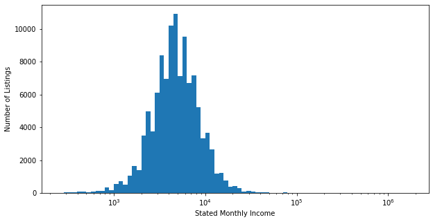

```python
# I will use log scle because of StatedMonthlyIncome large numbers
log_bin_size = 0.05
bins = 10 ** np.arange(2.4, np.log10(loans['StatedMonthlyIncome'].max())+log_bin_size, log_bin_size)
plt.figure(figsize=[10, 5 ])
plt.hist(data = loans, x = 'StatedMonthlyIncome', bins = bins)
plt.xscale('log')
plt.xlabel('Stated Monthly Income')
plt.ylabel('Number of Listings')
plt.show()
```

> The statistics shows that the data is right skewed with mean (5600 us dollar) more than the median (4666 us dollar). The chart prove this where most of the data lies between 1000 to 10000 us dollar.
- In order to see the percentage of loan monthly payment from their income, I will investigate DebtToIncomeRatio

```python
#DebtToIncomeRatio statitics
loans['DebtToIncomeRatio'].describe()
```

```
count    105383.000000
mean          0.275947
std           0.551759
min           0.000000
25%           0.140000
50%           0.220000
75%           0.320000
max          10.010000
Name: DebtToIncomeRatio, dtype: float64
```

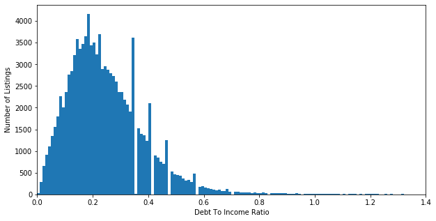

```python
#visualize these data
bin_size = 0.01
bins = np.arange(0, loans ['DebtToIncomeRatio'].max()+bin_size, bin_size)
plt.figure(figsize=[10, 5])
plt.hist(data = loans, x = 'DebtToIncomeRatio', bins = bins)
plt.xlim([0,1.4])
plt.xlabel('Debt To Income Ratio')
plt.ylabel('Number of Listings')
plt.show()
```

> It was noticed also that there are some outliers.
- Let's check the status of the borrower pervious loans through checking OnTimeProsperPayments
- OnTimeProsperPayments: is the number of on time payments the borrower had made on Prosper loans at the time they created this listing. This value will be null if the borrower has no prior loans.

```python
#OnTimeProsperPayments statistics
loans['OnTimeProsperPayments'].describe()
```

```
count    22085.000000
mean        22.271949
std         18.830425
min          0.000000
25%          9.000000
50%         15.000000
75%         32.000000
max        141.000000
Name: OnTimeProsperPayments, dtype: float64
```

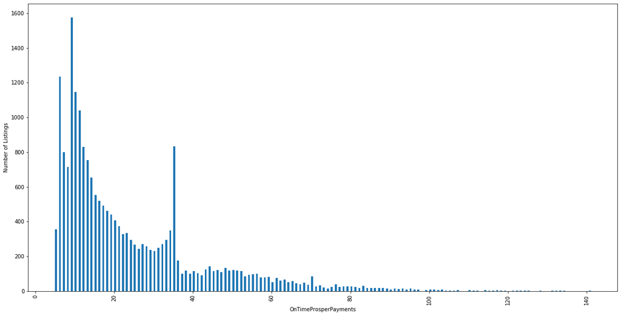

```python
# visualize these values
plt.figure(figsize=(20,10))
bins = np.arange(5, loans['OnTimeProsperPayments'].max()+0.5,0.5)
plt.hist(loans['OnTimeProsperPayments'], bins = bins)
plt.xlabel('OnTimeProsperPayments')
plt.ylabel('Number of Listings');
plt.xticks(rotation=90);
```

- Now we can check the upper and lower credit score for the brrowers

```python
#CreditScoreRangeUpper statistics
loans['CreditScoreRangeUpper'].describe()
```

```
count    113346.000000
mean        704.567731
std          66.458275
min          19.000000
25%         679.000000
50%         699.000000
75%         739.000000
max         899.000000
Name: CreditScoreRangeUpper, dtype: float64
```

```python
#CreditScoreRangelower statistics
loans['CreditScoreRangeLower'].describe()
```

```
count    113346.000000
mean        685.567731
std          66.458275
min           0.000000
25%         660.000000
50%         680.000000
75%         720.000000
max         880.000000
Name: CreditScoreRangeLower, dtype: float64
```

```python
#there are some null values here, we can fill it with mean
loans.CreditScoreRangeUpper = loans.CreditScoreRangeUpper.fillna(loans.CreditScoreRangeUpper.mean())
loans.CreditScoreRangeLower = loans.CreditScoreRangeLower.fillna(loans.CreditScoreRangeLower.mean())
```

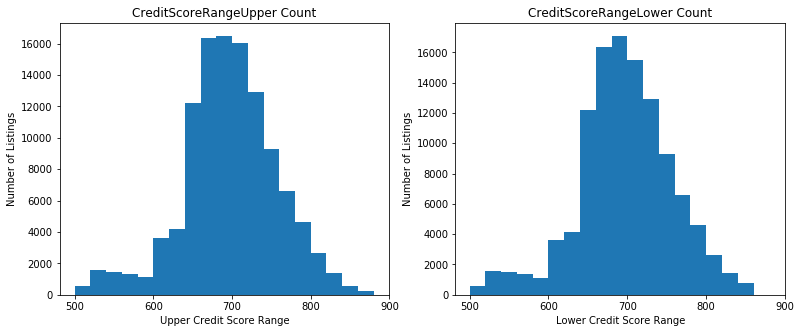

```python
#plot these data side by side
plt.figure(figsize = [13, 5])

plt.subplot(1, 2, 1)
bins = np.arange(500, loans['CreditScoreRangeUpper'].max(), 20)
plt.hist(data = loans, x = 'CreditScoreRangeUpper', bins = bins)
plt.xticks(np.arange(500, 1000, 100))
plt.title('CreditScoreRangeUpper Count')
plt.xlabel('Upper Credit Score Range')
plt.ylabel('Number of Listings');

plt.subplot(1, 2, 2)
bins = np.arange(500, loans['CreditScoreRangeLower'].max(), 20)
plt.hist(data = loans, x = 'CreditScoreRangeLower', bins = bins)
plt.xticks(np.arange(500, 1000, 100))
plt.title('CreditScoreRangeLower Count')
plt.xlabel('Lower Credit Score Range')
plt.ylabel('Number of Listings');
```

> It was noticed that the two charts are almost identical and symetrical, as the average value for the upper is 704 while for lower is 685.
- Finally let's check prosper score
- it's a custom risk score built using historical Prosper data. The score ranges from 1-10, with 10 being the best, or lowest risk score. Applicable for loans originated after July 2009.

```python
loans['ProsperScore'].describe()
```

```
count    84853.000000
mean         5.950067
std          2.376501
min          1.000000
25%          4.000000
50%          6.000000
75%          8.000000
max         11.000000
Name: ProsperScore, dtype: float64
```

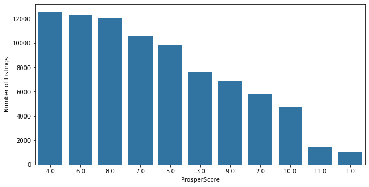

```python
# visualize these values
freq = loans['ProsperScore'].value_counts()
gen_order = freq.index
plt.figure(figsize=(10,5))
sb.countplot(data = loans , x = 'ProsperScore', color=base_color, order=gen_order)
plt.xlabel('ProsperScore')
plt.ylabel('Number of Listings');
#plt.xticks(rotation=90);
```

## Discuss the distribution(s) of your variable(s) of interest. Were there any unusual points? Did you need to perform any transformations?

The StatedMonthlyIncome variable took on a large range of values, so I looked at the data using a log transform. Quit few data has null values that I fill with mean. No there is no need any transfromation.

## Of the features you investigated, were there any unusual distributions? Did you perform any operations on the data to tidy, adjust, or change the form of the data? If so, why did you do this?

- When I was investigating the LoanStatus, I change its type to make its ploting easer.
- I found some outlier in DebtToIncomeRatio.
- Upper and lower cerditRangScore have normal distribution while MonthlyLoanPayment and onTimeProsperPayment have Skewed right.

## Bivariate Exploration.

#### I will check first the correlation between the data

I will make the correlation using heatmap. A heatmap is a two-dimensional graphical representation of data where the individual values that are contained in a matrix are represented as colors.

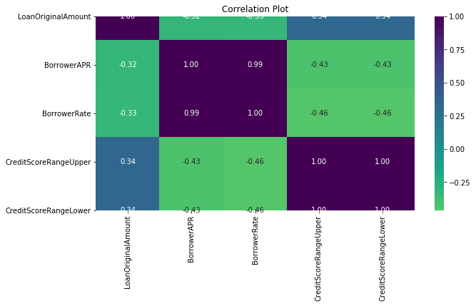

```python
# first correlation is between the loan chractristics
num_var = ['LoanOriginalAmount', 'BorrowerAPR', 'BorrowerRate', 'CreditScoreRangeUpper', 'CreditScoreRangeLower']
# correlation plot
plt.figure(figsize = [10, 5])
sb.heatmap(loans[num_var].corr(), annot = True, fmt = '.2f', cmap = 'viridis_r', center = 0)
plt.title('Correlation Plot')
plt.show()
```

> There are positive strong relation between borrowerAPR and borrowerRate and between upper and lower credit score; in which it's logic as APR depend on Rate. But for any other pair, there are no strong positive relationships. -ve sign for borrower rate and APR with cridet score is logic alos as higher credit score means the borrowers are more trusted, therefore it recevied lower APR.

Let's see now the plot matrix for each pair

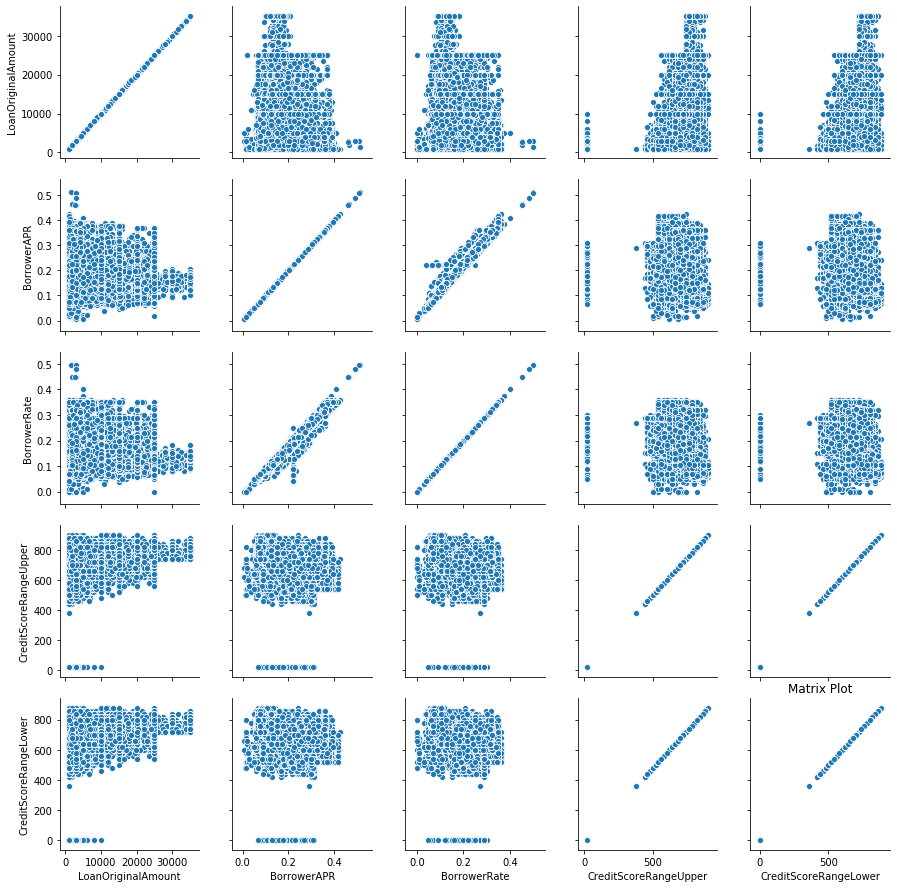

```python
#I chose sample of 5000 record
loan_samp = loans.sample(5000)
loan_charc = sb.PairGrid(data = loans, vars = num_var)
loan_charc.map(sb.scatterplot)
plt.title('Matrix Plot');
```

> Similar to the correlation plot, there are strong positive relation between upper and lower credite score; and borrowerAPR and borrowerRate. LoanOrignalAmount dosen't give usefule information on any of BorrowerAPR or credit score, so it will be excluded from the analysis.

#### Now Let's see if there is a relation between these variables and the categorical variables. I will began with EmploymentStatus

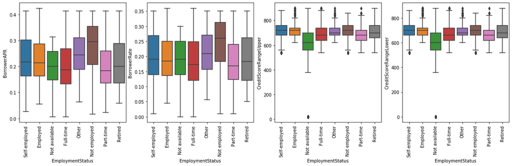

```python
#use boxplot and subplot
plt.figure(figsize = [20, 5])
base_color = sb.color_palette()[0]

# left plot: BorrowerAPR
plt.subplot(1, 4, 1)
ax = sb.boxplot(y="BorrowerAPR", x="EmploymentStatus", data=loans)
plt.xticks(rotation=90);

# left center plot: BorrowerRate
plt.subplot(1, 4, 2)
ax = sb.boxplot(y="BorrowerRate", x="EmploymentStatus", data=loans)
plt.xticks(rotation=90);

# right center plot: CreditScoreRangeUpper
plt.subplot(1, 4, 3)
ax = sb.boxplot(y="CreditScoreRangeUpper", x="EmploymentStatus", data=loans)
plt.xticks(rotation=90);

# right plot: CreditScoreRangeLower
plt.subplot(1, 4, 4)
ax = sb.boxplot(y="CreditScoreRangeLower", x="EmploymentStatus", data=loans)
plt.xticks(rotation=90);
```

From this I found that borrowers with lower APR are retaired, part time and full time jobs. While the largest APR is for not employed which is logic. this is also relected on BorrowerRate. For credit score I found that borrowers with lower score (upper and lower)is that havn't identifyed jobs

#### To study the relation between BorrowerAPR and LoanStatus,I plot factgrid to check which statuse has more APR

[figure not shown]

```python
# Plot LoanStatus vs borrowerAPR as FacetGrid
g = sb.FacetGrid(data = loans, col = 'LoanStatus',  col_wrap = 6)
g.map(plt.hist, "BorrowerAPR");
```

this result confirm what we have found pervisuly that most of the loans are completed or currently on progress. But Also noticed that APR is almost the same with loans with past due date. So this parameter dosen't give any good analysis.

#### Let's investigate the other variables

Second correlation is between the brrower income chractristics

- I will investigatite if there is a correlation between: 'MonthlyLoanPayment', 'IncomeRange', 'StatedMonthlyIncome', 'DebtToIncomeRatio', 'OnTimeProsperPayments'

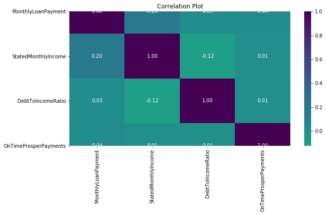

```python
# correlation is between the brrower income chractristics
num_var2= ['MonthlyLoanPayment', 'IncomeRange', 'StatedMonthlyIncome', 'DebtToIncomeRatio', 'OnTimeProsperPayments' ]
# correlation plot
plt.figure(figsize = [10, 5])
sb.heatmap(loans[num_var2].corr(), annot = True, fmt = '.2f', cmap = 'viridis_r', center = 0)
plt.title('Correlation Plot')
plt.show()
```

> There are no positive relations between these variables.

> We will check it further by matrix scatter plot

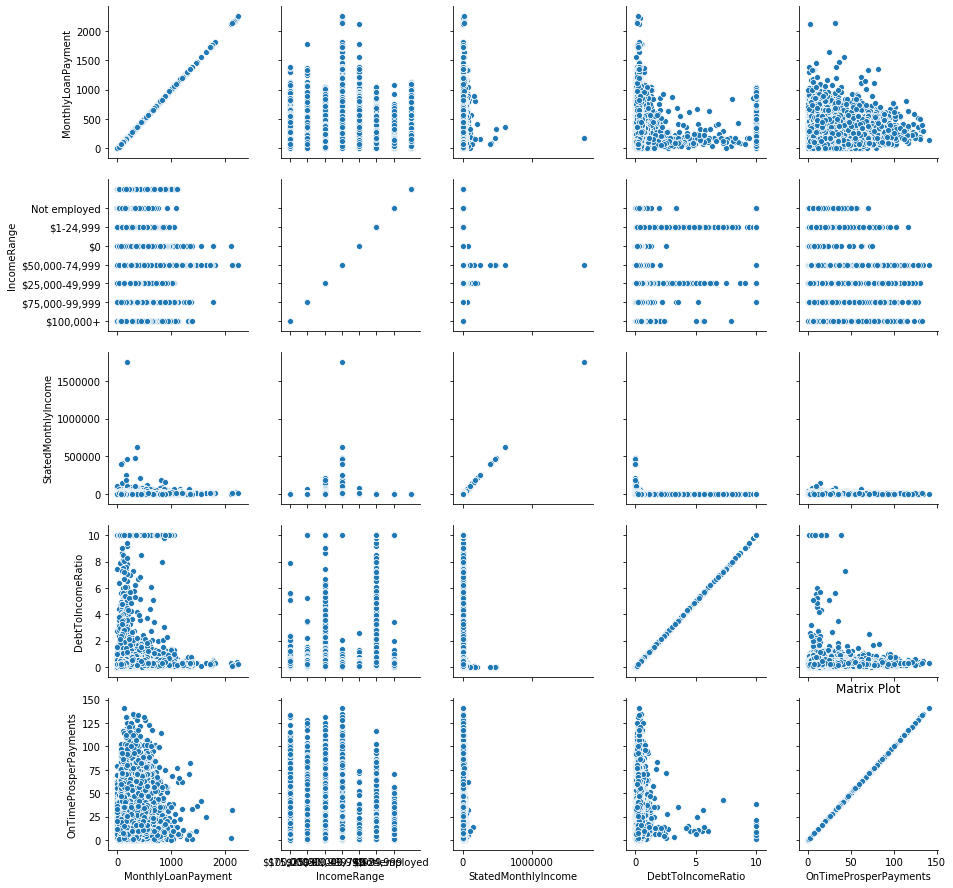

```python
#I chose sample of 5000 record
loan_samp = loans.sample(5000)
loan_charc = sb.PairGrid(data = loans, vars = num_var2)
loan_charc.map(sb.scatterplot)
plt.title('Matrix Plot');
```

Similar to the correlation plot, there is no strong postive relations. This prove that there is no relation between the monthly loan payment and the income for the borrower.

Now I will analysis categorical parameter

[figure not shown]

```python
plt.figure(figsize = [20,10])
ax = sb.countplot(x="ListingCategory (numeric)", hue = 'LoanStatus',  data=loans, palette = 'Set2')
xlabels = ['0-Not Available', '1-Debt Consolidation', '2-Home Improvement', '3-Business', '4-Personal Loan', '5-Student Use', '6-Auto', '7-Other', '8-Baby&Adoption', '9-Boat', '10-Cosmetic Procedure', '11-Engagement Ring', '12-Green Loans', '13-Household Expenses', '14-Large Purchases', '15-Medical/Dental', '16-Motorcycle', '17-RV', '18-Taxes', '19-Vacation', '20-Wedding Loans']
ax.set_xticklabels(xlabels, rotation=90);
```

[figure not shown]

```python
# investigation of relation between employment status and loan status
ax = sb.countplot(x="EmploymentStatus", hue = 'LoanStatus',  data=loans)
plt.xticks(rotation=90);
```

Here I found that employed borrower has the maximum numbre of current loan status while full time job has the maximum number of compledted loan status.

[figure not shown]

```python
# occupation  Vs loanStatus
plt.figure(figsize = [25,15])
ax = sb.countplot(x="Occupation", hue = 'LoanStatus',  data=loans, palette = "Set2")
plt.xticks(rotation=90);
```

Also here I found that when occupation is other it has the maximum number of completer and current loan status followed by professional.

From all of this we conclude that:

## Talk about some of the relationships you observed in this part of the investigation. How did the feature(s) of interest vary with other features in the dataset?

- There are positive strong relation between borrowerAPR and borrowerRate and between upper and lower credit score
- I found that borrowers with lower APR are retaired, part time and full time jobs. While the largest APR is for not employed which is logic. this is also reflected on BorrowerRate. For credit score I found that borrowers with lower score (upper and lower)is that havn't identifyed jobs
- There is no correlation beween 'MonthlyLoanPayment', 'IncomeRange', 'StatedMonthlyIncome', 'DebtToIncomeRatio', 'OnTimeProsperPayments'

## Multivariate Exploration

> In order to study deplly the relation between 'DebtToIncomeRatio', 'BorrowerAPR' and 'ProsperScore' I will plot the three variables against each other

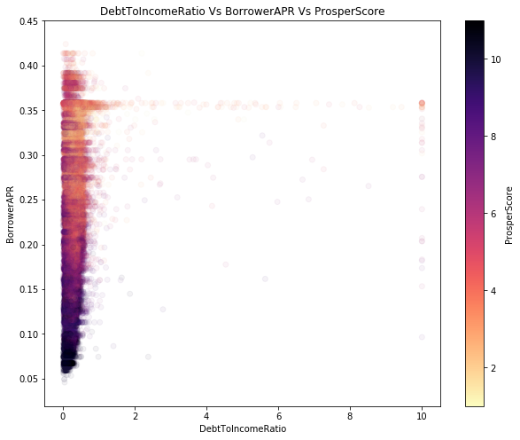

```python
# Scatter plot to show relationship between 'DebtToIncomeRatio', 'BorrowerAPR' and 'ProsperScore'

plt.figure(figsize = [10,8])
plt.scatter(data=loans, x='DebtToIncomeRatio', y='BorrowerAPR', c='ProsperScore', cmap='magma_r', alpha=0.05);
cbar = plt.colorbar(label='ProsperScore')
cbar.solids.set(alpha=1)
plt.title('DebtToIncomeRatio Vs BorrowerAPR Vs ProsperScore');
plt.xlabel('DebtToIncomeRatio')
plt.ylabel('BorrowerAPR');
```

From this chart it seems the best APR is below 0.1 for borrowers with prosper score more than 10. Also the best dept to income ratio is for less than 1.

I now will study the effect of time on income range and listing category

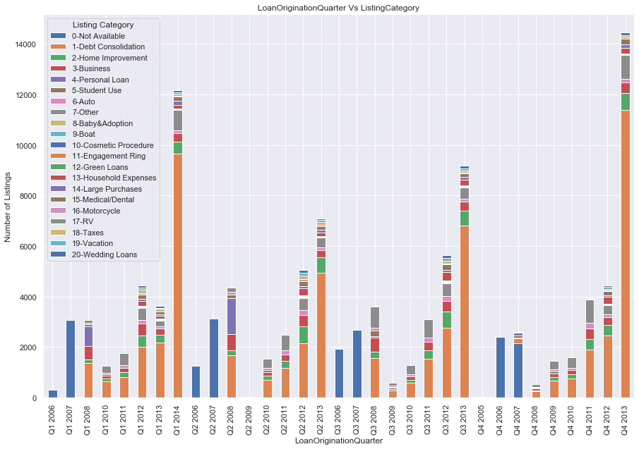

```python
# create legend label descriptions and visualize the data using multivariate plot
listing_plot = loans.groupby(['ListingCategory (numeric)', 'LoanOriginationQuarter']).size().reset_index().pivot(columns='ListingCategory (numeric)', index='LoanOriginationQuarter', values=0)
listing_plot.plot(kind='bar', stacked=True)

plt.legend(['0-Not Available', '1-Debt Consolidation', '2-Home Improvement', '3-Business', '4-Personal Loan', '5-Student Use', '6-Auto', '7-Other', '8-Baby&Adoption', '9-Boat', '10-Cosmetic Procedure',
              '11-Engagement Ring', '12-Green Loans', '13-Household Expenses', '14-Large Purchases','15-Medical/Dental', '16-Motorcycle', '17-RV', '18-Taxes', '19-Vacation', '20-Wedding Loans'], title='Listing Category')
sb.set(rc={'figure.figsize':(15, 10)})
plt.title('LoanOriginationQuarter Vs ListingCategory')
plt.ylabel('Number of Listings')
plt.xlabel('LoanOriginationQuarter')
plt.xticks(rotation=90);
```

It has been noticed here that starting from year 2008 the borrowers beagins their loans and that Dept consolidation is the king amoung all of those loans. Also the loans has a large increase starting from last quarntile for 2013.

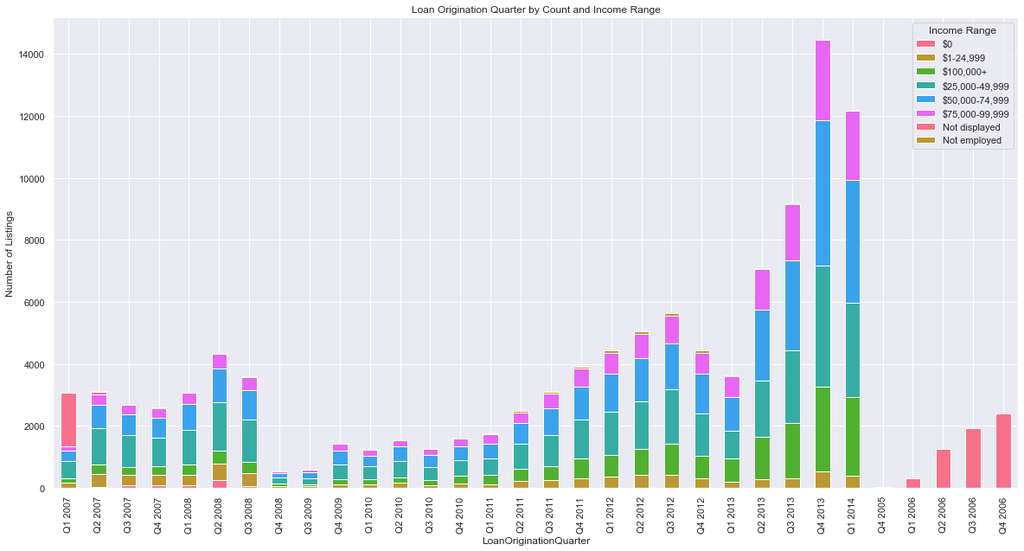

```python
# make the 'LoanOriginationQuarter' categorical data type
quarter = ['Q4 2005', 'Q1 2006', 'Q2 2006', 'Q3 2006', 'Q4 2006', 'Q1 2007', 'Q2 2007', 'Q3 2007', 'Q4 2007', 'Q1 2008', 'Q2 2008', 'Q3 2008', 'Q4 2008', 'Q1 2009'
          'Q2 2009', 'Q3 2009', 'Q4 2009', 'Q1 2010', 'Q2 2010', 'Q3 2010', 'Q4 2010', 'Q1 2011', 'Q2 2011', 'Q3 2011', 'Q4 2011', 'Q1 2012', 'Q2 2012', 'Q3 2012', 'Q4 2012',
          'Q1 2013', 'Q2 2013', 'Q3 2013', 'Q4 2013', 'Q1 2014']
cat = pd.api.types.CategoricalDtype(categories=quarter, ordered=True)
loans['LoanOriginationQuarter'] = loans['LoanOriginationQuarter'].astype(cat)
loans = loans.loc[loans['LoanOriginationQuarter'].isin(['Q4 2005', 'Q1 2006', 'Q2 2006', 'Q3 2006', 'Q4 2006', 'Q1 2007', 'Q2 2007', 'Q3 2007', 'Q4 2007', 'Q1 2008', 'Q2 2008', 'Q3 2008', 'Q4 2008',
          'Q1 2009' ,'Q2 2009', 'Q3 2009', 'Q4 2009', 'Q1 2010', 'Q2 2010', 'Q3 2010', 'Q4 2010', 'Q1 2011', 'Q2 2011', 'Q3 2011', 'Q4 2011', 'Q1 2012', 'Q2 2012', 'Q3 2012', 'Q4 2012',
          'Q1 2013', 'Q2 2013', 'Q3 2013', 'Q4 2013', 'Q1 2014'])]

#visualize the data using multivariate plot
sb.set(rc={'figure.figsize':(20, 10)})
sb.set_palette('husl')
loanquart_plot = loans.groupby(['IncomeRange', 'LoanOriginationQuarter']).size().reset_index().pivot(columns='IncomeRange',
                                index='LoanOriginationQuarter', values=0)
loanquart_plot.plot(kind='bar', stacked=True)
plt.legend(title='Income Range')
plt.title('Loan Origination Quarter by Count and Income Range')
plt.ylabel('Number of Listings')
plt.xlabel('LoanOriginationQuarter')
plt.xticks(rotation=90);
```

Here the chart illustaring why loans starts from 2013, the income range has noticable increase in this period. The sallary ranges of 75-99 and +100 thousand dollar increase starting from 2013.  
It looks like the income ranges uptick in loans in 2012-2013. It grew initially in 50k-75k, 75k-100k, and 100k+.

## Talk about some of the relationships you observed in this part of the investigation. Were there features that strengthened each other in terms of looking at your feature(s) of interest?

I investigate deeply in two prances. the first one is for the relation between 'DebtToIncomeRatio', 'BorrowerAPR' and 'ProsperScore'. I found that the best APR is below 0.1 for borrowers with prosper score more than 10. Also the best dept to income ratio is for less than 1.  
The second one is for the effect of time on income range and listing category. I found that by 2013 the income increase and subsequently the loans increase.

## Were there any interesting or surprising interactions between features?

It was interesting to me the reflection of the financial crises in 2008 on loans and banks. Iwas surprised also that banks could give loans to people with no identified income.

```python
from subprocess import call
call(['python', '-m', 'nbconvert', 'ProsperLoanProject_results_notebook.ipynb'])
```

```
4294967295
```